# BIOS 611 Project 1

Christina Zhou

10/7/2019

#### Introduction

Homelessness is defined as any person living without a home, typically living on the streets. In North Carolina, the Continuums of Care to the U.S. Department of Housing and Urban Development (HUD) reported approximately 9,268 people experience homelessness on any given day as of January 2018 (1). Shelters and volunteers attempt to lower this number by providing resources that can potentially help a person or family find the means to obtain a home, and thus stop living on the streets. One of these shelters in Durham, North Carolina, is Urban Ministries of Durham (UMD). Established in 1983, UMD is a non-profit organization that focuses on lowering the community’s rate of homelessness by providing food, shelter and other resources to those in need. In 2001, three organizations (Durham Community Shelter for HOPE, St. Philip’s Community Cafe, and the United Methodist Mission Society) merged to create UMD as it exists today. UMD strives to holistically lower Durham’s homelessness rates with the help from the Durham community and over 4,000 volunteers. UMD provides “food, shelter, and a future” to over 6,000 men, women, and children every year (2). In our exploratory analysis for Project 1, we seek to explore the trends of household types that visit UMD, regarding number of visits and amount of food. For this project, we focus our data analysis on examining the relationship of number of visits and average pounds of food per visit between family households and single households. We would expect family households to obtain more food, and perhaps have less visits to UMD (maybe because they are trying harder to find a sustainable home due to more members at stake).

#### Data source

The data for our analysis is from UMD. UMD has been collecting data about people who utilize its resources for decades. This data includes an identifier (ID), date of visit, number of people the food from that visit provided for, pounds of food taken from food pantry, amount of clothing taken from clothing closet, and more. The total number of observations of this data is 79838. Variable descriptions for the UMD data can be found here: https://github.com/biodatascience/datasci611/blob/gh-pages/data/project1_2019/UMD_Services_Provided_metadata_20190719.tsv

#### Data cleaning and preliminary examinations

Since UMD as it is known today was created in 2001, we truncate our dataset to be collected data from January 1, 2001 to the last date of a full year, which is December 31, 2018. Since the data for 2019 is not complete, we omit data that was collected after December 31, 2018.

To examine the trends of visits and food obtained between family and single households, we define an observation as part of a family household if the number of people the food given that visit was provided for more than 1 person, and as a single household otherwise. Because of this, we want to limit our population to those who are not missing data for the Food.Provided.for (defined as number of people the food given that visit was provided for) and Food.Pounds (defined as the number of pounds given for that visit) variables.

| Client.File.Number | Number_of_Visits | First_Visit_Year | Last_Visit_Year | Range |
| --- | --- | --- | --- | --- |
| 255 | 117 | 2005 | 2018 | 14 |
| 1176 | 117 | 2006 | 2018 | 13 |
| 805 | 115 | 2009 | 2018 | 10 |
| 5228 | 114 | 2007 | 2018 | 12 |
| 4098 | 111 | 2006 | 2018 | 13 |
| 738 | 111 | 2006 | 2017 | 12 |
| 6526 | 104 | 2009 | 2018 | 10 |
| 7266 | 102 | 2009 | 2018 | 10 |
| 5963 | 96 | 2009 | 2018 | 10 |
| 967 | 91 | 2006 | 2018 | 13 |

Since we are primarily interested in the relationship between household type for this analysis, we subset our analysis population further by only keeping observations with the same number of family members for every visit. We do this because we want to keep consistency in our dataset in terms of defining family vs. single households. We note that changing this subset may be done in a different analysis if a later question of interest involves examining changes number of family household over time. Additionally, we remove observations with who do not take food from UMD (meaning, the maximum pounds of food for all visits is 0) since we are only examining subjects who take food. In the first table below are the top 5 remaining observations, sorted in descending order by the number of family members. The second table below are the top 15 remaining observations, sorted in descending order by mean pounds of food per day per household.

| Client.File.Number | Number_of_Visits | Number_of_Members | mean_food_pounds_per_day |
| --- | --- | --- | --- |
| 13736 | 1 | 650 | 6 |
| 1180 | 1 | 200 | 1700 |
| 11585 | 1 | 115 | 0 |
| 12458 | 1 | 47 | 30 |
| 9575 | 1 | 23 | 20 |

| Client.File.Number | Number_of_Visits | Number_of_Members | mean_food_pounds_per_day |
| --- | --- | --- | --- |
| 16043 | 1 | 2 | 1934.00000 |
| 1370 | 1 | 1 | 1831.00000 |
| 1180 | 1 | 200 | 1700.00000 |
| 14318 | 2 | 1 | 923.00000 |
| 15000 | 8 | 6 | 708.87500 |
| 14151 | 4 | 1 | 469.75000 |
| 13749 | 10 | 2 | 211.10000 |
| 13850 | 1 | 1 | 158.00000 |
| 13972 | 1 | 1 | 158.00000 |
| 15022 | 7 | 4 | 85.57143 |
| 7857 | 1 | 7 | 60.00000 |
| 7884 | 1 | 7 | 60.00000 |
| 8432 | 1 | 7 | 60.00000 |
| 8656 | 2 | 7 | 60.00000 |
| 8798 | 1 | 7 | 60.00000 |

| Client.File.Number | Number_of_Visits | Number_of_Members | mean_food_pounds_per_day | family |
| --- | --- | --- | --- | --- |
| 15022 | 7 | 4 | 85.57143 | 1 |
| 13693 | 6 | 7 | 60.00000 | 1 |
| 11566 | 3 | 7 | 60.00000 | 1 |
| 12192 | 3 | 7 | 60.00000 | 1 |
| 8656 | 2 | 7 | 60.00000 | 1 |

Thus, our final analysis population is 7191 households. From the table below, we can see that the split between number of family households and number of single households is relatively even. Recall the variable family is an indicator where family = 1 means the household is a family household and family = 0 means the household is a single household.

| family | Total Count |
| --- | --- |
| 0 | 3405 |
| 1 | 3786 |

#### Main Analysis

Figure 1 below displays two boxplots, comparing the average number of pounds of food taken from the UMD food pantry per day between household types (single-member households vs. family households). As expected, those with families have a higher overall mean per day. Additionally, there are more and larger outliers for larger average pounds per day for the family households than single-member households. Similarly, single-member households have more lower outliers for average pounds per day compared to family households. This is expected, since family households have more people to feed than single households.

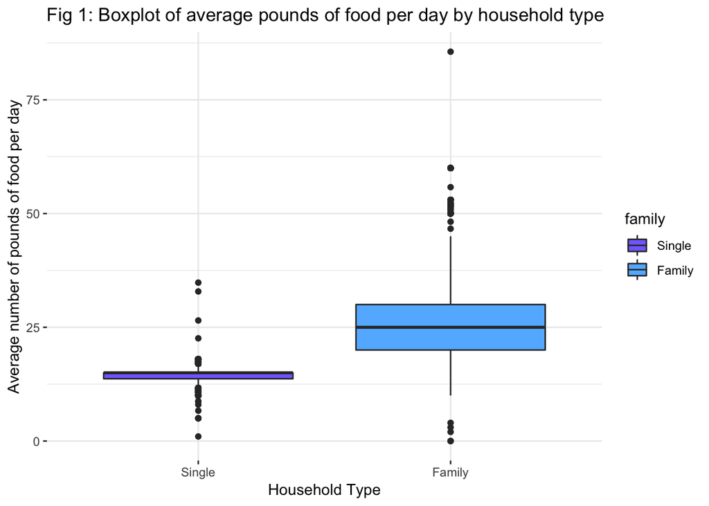

In Figure 2a below, we see two boxplots of total number of visits in last 20 years per household, comparing single-member households vs. family households. From this figure, we can see that for both household types, the overall average number of total visits in the last 20 years is low. It is also seen from Figure 2a that that there is a larger quantity of outliers for single households than family households. The variance is larger as a result (wider spread). Similarly, some of these outliers are more extreme than those of the family household total visits. One reason for the larger variance in single family household is that single people may come in whenever they need to, but families may try to be more consistent since they may be more aware of the fact that they will need food. This is possibly because of the feeling of higher risk of taking care of someone more than just oneself. Figure 2b compares the boxplots but only for total number of visits that are less than or equal to 60.

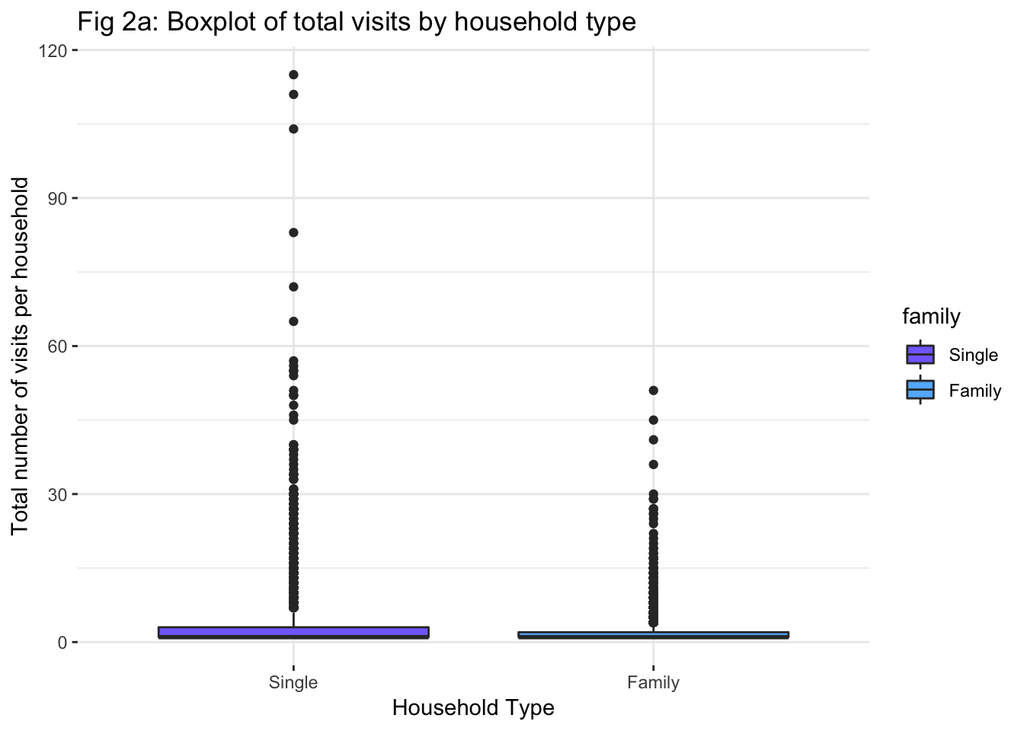

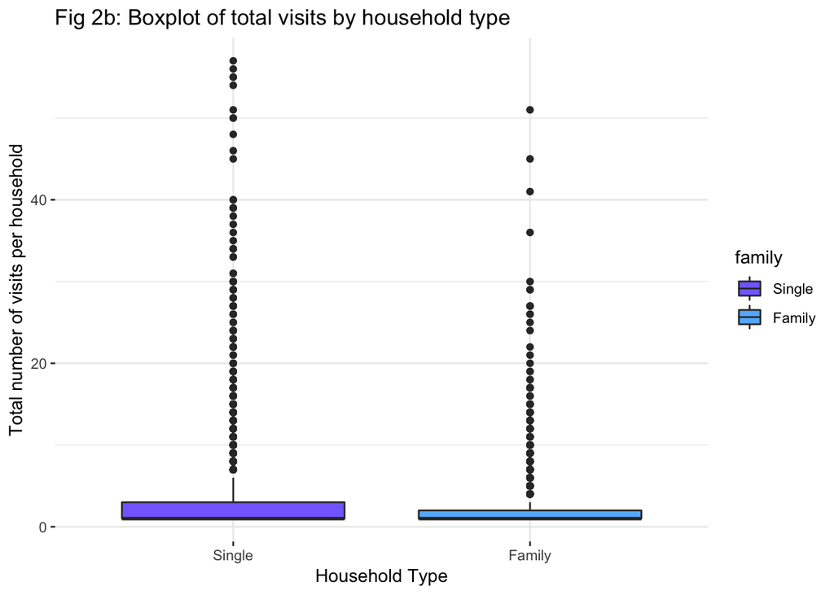

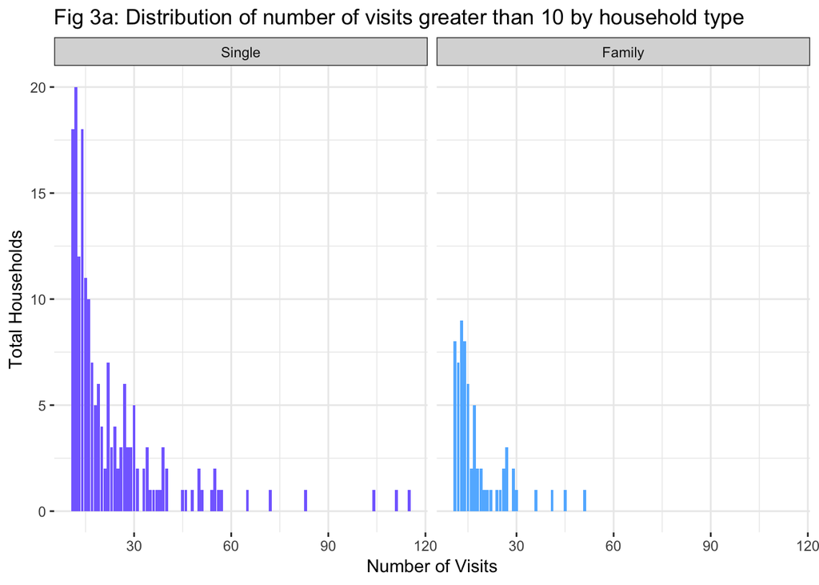

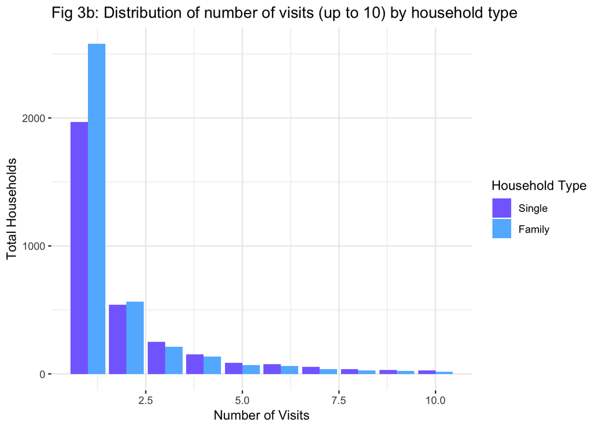

In conclusion, we examined two trends comparing household types. The first trend confirms that families have on average greater average pounds of food per day from the pantry. The second trend reveals that families tend to visit less often than single households. However, most households for both household types tend to have “fewer visits” compared to “more visits”.

#### References

1. https://www.usich.gov/homelessness-statistics/nc/
2. http://www.umdurham.org/